# Title of your article goes here

# Comparing Voteview-based scores to those presented in Edwards (1985)

We begin by loading data from Edwards (1985), Table 2 as well as the aggregate scores that we just created and merging those two datasets.

```r
agg_support <- read_csv("presidential_support_summary.csv") %>%
   filter(chamber=="house")
edwards <- read_csv("edwards_1985_support_scores.csv")
agg_support <- agg_support %>% left_join(edwards)
```

We can then plot our chamber-level scores against those reported by Edwards:

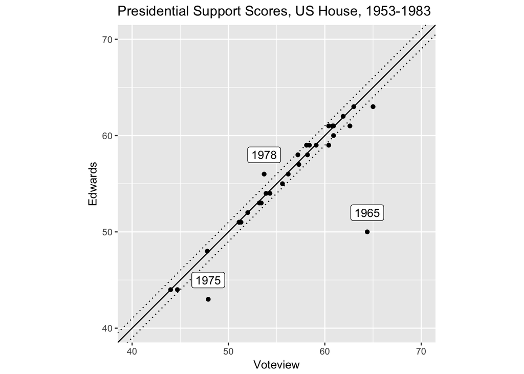

Across the 31 years for which Edwards reports scores, there are only three years in which the difference between what Edwards reports and what we compute based on the Voteview data is greater than 2 percentage points. Those years are 1965, 1975, and 1978. We have not uncovered the source of these three larger discrepancies.

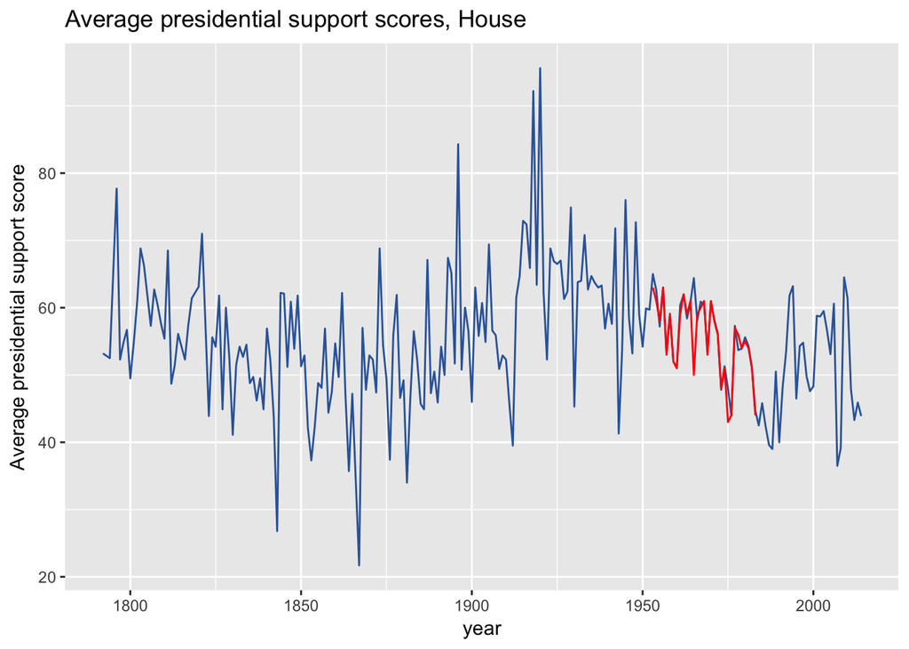

# Support scores over time

Finally, we plot the presidential support scores for all House members and all Senate members across all years. Each point represents a member in a particular year. The points are “jittered” by small random shocks so that clusters of members with the same score in the same year can be distinguished.

## House of Representatives

Prior to 1950, the number of votes upon which the scores are based are relatively small and the number of distinct scores is small with large numbers of members generally piling up at each possible value.

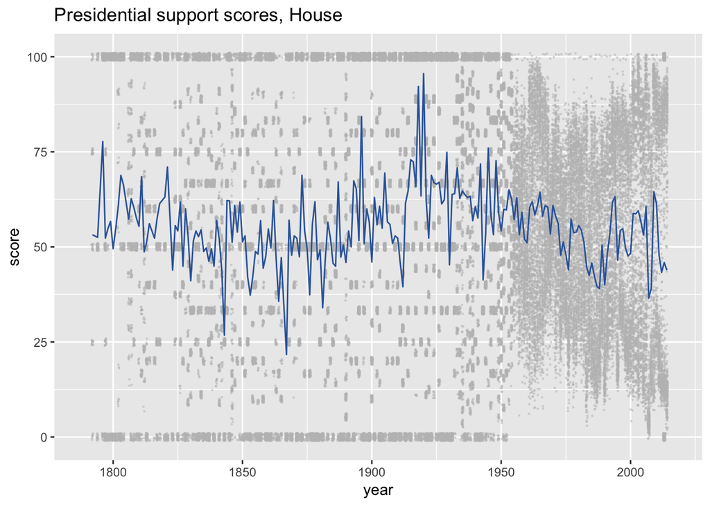

## Senate

Note that at the moment the database does not include the presidents’ positions on roll calls taken in the Senate prior to 1955.

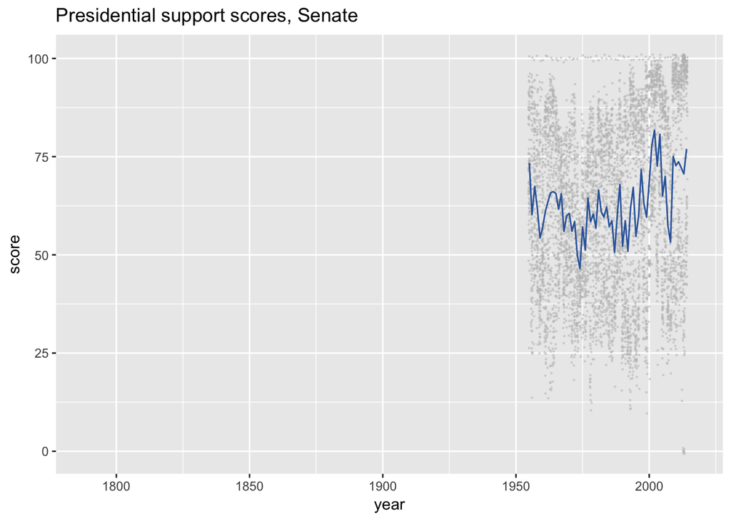